# Self-Driving Car Engineer Nanodegree

### 3.2 The Model's Predictions on the New Images

```python
### Run the predictions here.
### Feel free to use as many code cells as needed.
def predict(img):
    """Print model's prediction of which traffic sign this image is."""
    classification = sess.run(tf.argmax(pred, 1), feed_dict={x_unflattened: [img]})
    print(classification)
    print('NN predicted', classification[0])
```

```python
def show_and_pred_X_train(index):
    """Show image from training set and print model's prediction
    (of which traffic sign this image is).
    """
    plt.imshow(X_train[index])
    predict(X_train[index])
```

```python
def show_and_pred_image(image):
    """Show image and print model's prediction (of which traffic
    sign this image is).
    """
    plt.imshow(image)
    predict(image)
```

```python
def read_show_and_pred_image(image_path):
    """Read image, show image and print model's prediction (of
    which traffic sign this image is).
    """
    # Read in image from file
    image = mpimg.imread(image_path)
    # Show image
    # Call as plt.imshow(gray, cmap='gray') to show a grayscaled image
    plt.imshow(image)
    predict(image)
    return image
```

```
[4]
NN predicted 4
```

[figure not shown]

```python
show_and_pred_X_train(40)
```

```python
def read_show_and_pred_image_tsdata(image_name):
    """Read image from dir `traffic-sign-data`, show image and print model's prediction (of
    which traffic sign this image is).
    """
    return read_show_and_pred_image('traffic-sign-data/' + image_name)
```

```
[40]
NN predicted 40
```

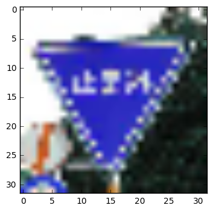

```python
japanese_sign = read_show_and_pred_image_tsdata("japanese_sign_resized.png")
```

This is a Japanese stop sign, though it looks like a Yield sign. The network predicts this is a Roundabout Mandatory sign, which is completely different.

```
[11]
NN predicted 11
```

[figure not shown]

```python
german_sign = read_show_and_pred_image_tsdata("german_sign_resized.png")
```

This is a no parking zone sign. The network predicts this is a 'Right-of-way at the next intersection' sign. They are not similar.

```
[37]
NN predicted 37
```

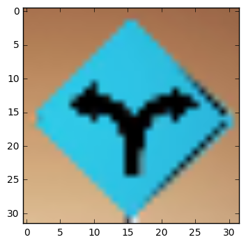

```python
two_way_sign = read_show_and_pred_image_tsdata("two_way_sign_resized.png")
```

The network predicts this is a Go straight or left sign. They are similar in that there precisely two curved arrows in both signs.

```
[40]
NN predicted 40
```

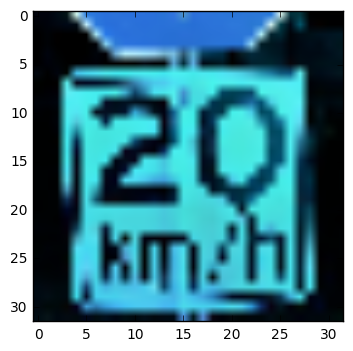

```python
speed_limit_stop = read_show_and_pred_image_tsdata("speed_limit_stop_resized.png")
```

The network predicts this is a roundabout mandatory sign (40). This is wrong- it should be 20km/h speed limit (0). The network may have been confused by the many curves that make up the sign.

```
[40]
NN predicted 40
```

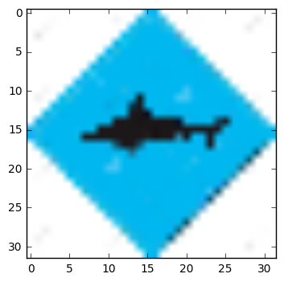

```python
shark_sign = read_show_and_pred_image_tsdata("shark_sign_resized.png")
```

The network predicts this is a roundabout mandatory sign. This is wrong, but then there is no correct class within the 43 for this sign.

- It is unclear why this sign should be the roundabout mandatory sign of all signs.
  - There are not many curved arrows - the black portion of the sign is small and is close to a short horizontal line segment in the middle of the sign.
  - The diamond-shaped sign could have indicated Priority Road (12).

### Question 7

*Is your model able to perform equally well on captured pictures or a live camera stream when compared to testing on the dataset?*

**Answer:**

(Answer applied to captured pictures)

It seems that the model is classifying 'unknown signs' as Roundabout Mandatory signs.

Reference for images of correct German signage: http://www.gettingaroundgermany.info/zeichen.shtml

### 3.3 Visualising the certainty of the model's predictions

```python
### Visualize the softmax probabilities here.
### Feel free to use as many code cells as needed.

def certainty_of_predictions(img):
    """Return model's top five choices for what traffic sign
    this image is and its confidence in its predictions.
    """
    top_five = sess.run(tf.nn.top_k(tf.nn.softmax(pred), k=5), feed_dict={x_unflattened: [img]})
    print("Top five: ", top_five)
    return top_five
```

```python
def show_and_pred_certainty_image(image):
    plt.imshow(image)
    return certainty_of_predictions(image)
```

```python
def show_and_pred_certainty_X_train(index):
    """Show image from training set and print model's certainty of its
    prediction (of which traffic sign this image is).
    """
    plt.imshow(X_train[index])
    return certainty_of_predictions(X_train[index])
```

```python
sign_names = pd.read_csv("signnames.csv")
sign_names.head()
```

|  | ClassId | SignName |
| --- | --- | --- |
| 0 | 0 | Speed limit (20km/h) |
| 1 | 1 | Speed limit (30km/h) |
| 2 | 2 | Speed limit (50km/h) |
| 3 | 3 | Speed limit (60km/h) |
| 4 | 4 | Speed limit (70km/h) |

```python
def plot_certainty_arrays(probabilities, labels):
    """Plot model's probabilities (y) and traffic sign labels (x)
    in a bar chart.
    """
    y_pos = np.arange(len(labels))
    performance = [10,8,6,4,2,1]

    plt.bar(y_pos, probabilities, align='center', alpha=0.5)
    plt.xticks(y_pos, labels)
    plt.ylabel('Probability')
    plt.xlabel('Traffic sign')
    plt.title('Model\'s certainty of its predictions')

    plt.show()
    print("Traffic Sign Key")
    for label in labels:
        print(label, ": ", sign_names.loc[label]['SignName'])
```

```
Top five:  TopKV2(values=array([[  9.99999881e-01,   8.97579966e-08,   7.74691075e-12,
          3.65528658e-12,   3.18651193e-13]], dtype=float32), indices=array([[ 4,  1, 33,  2, 24]], dtype=int32))
```

```
TopKV2(values=array([[  9.99999881e-01,   8.97579966e-08,   7.74691075e-12,
          3.65528658e-12,   3.18651193e-13]], dtype=float32), indices=array([[ 4,  1, 33,  2, 24]], dtype=int32))
```

[figure not shown]

```python
show_and_pred_certainty_X_train(40)
```

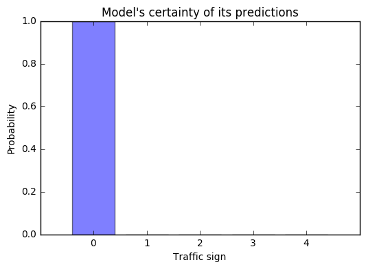

```
Traffic Sign Key
0 :  Speed limit (20km/h)
1 :  Speed limit (30km/h)
2 :  Speed limit (50km/h)
3 :  Speed limit (60km/h)
4 :  Speed limit (70km/h)
```

```python
plot_certainty_arrays([ 1.,  0.,  0.,  0.,  0.], [0, 1, 2, 3, 4])
```

```
Top five:  TopKV2(values=array([[  9.98222530e-01,   1.62888202e-03,   1.46346400e-04,
          1.53178951e-06,   5.86885108e-07]], dtype=float32), indices=array([[40, 38, 11, 36, 41]], dtype=int32))
```

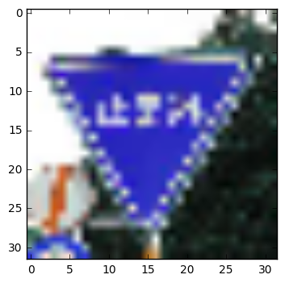

```python
japanese_sign_certainties = show_and_pred_certainty_image(japanese_sign)
```

```python
japanese_sign_certainties[1][0]
```

```
40
```

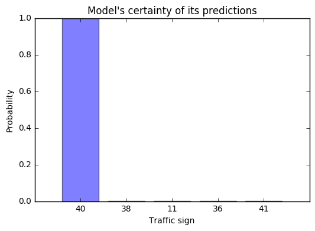

```
Traffic Sign Key
40 :  Roundabout mandatory
38 :  Keep right
11 :  Right-of-way at the next intersection
36 :  Go straight or right
41 :  End of no passing
```

```python
plot_certainty_arrays(japanese_sign_certainties[0][0],
                      japanese_sign_certainties[1][0])
```

```
Top five:  TopKV2(values=array([[  9.99230623e-01,   7.54820358e-04,   1.45532485e-05,
          4.02383478e-08,   6.02914774e-10]], dtype=float32), indices=array([[11,  1, 41, 18, 30]], dtype=int32))
```

[figure not shown]

```python
german_sign_certainties = show_and_pred_certainty_image(german_sign)
```

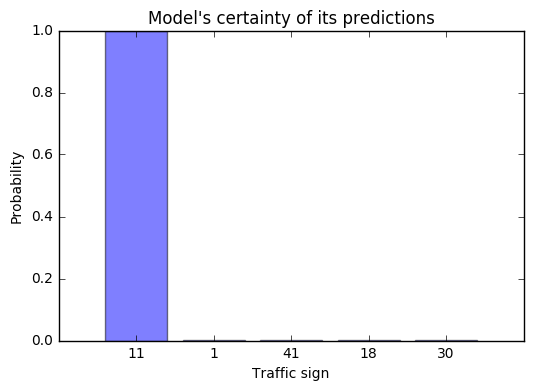

```
Traffic Sign Key
11 :  Right-of-way at the next intersection
1 :  Speed limit (30km/h)
41 :  End of no passing
18 :  General caution
30 :  Beware of ice/snow
```

```python
plot_certainty_arrays(german_sign_certainties[0][0],
                      german_sign_certainties[1][0])
```

```
Top five:  TopKV2(values=array([[  9.79143798e-01,   2.04710234e-02,   3.73480958e-04,
          1.17034851e-05,   2.33219186e-08]], dtype=float32), indices=array([[33, 40, 39, 37, 41]], dtype=int32))
```

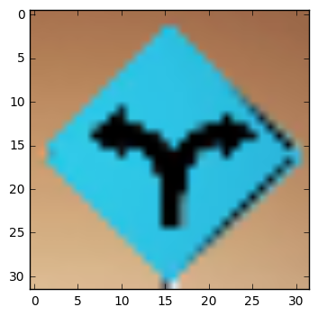

```python
two_way_sign_certainties = show_and_pred_certainty_image(two_way_sign)
```

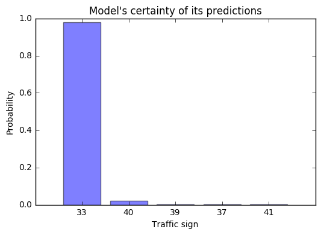

```
Traffic Sign Key
33 :  Turn right ahead
40 :  Roundabout mandatory
39 :  Keep left
37 :  Go straight or left
41 :  End of no passing
```

```python
plot_certainty_arrays(two_way_sign_certainties[0][0], two_way_sign_certainties[1][0])
```

```
Top five:  TopKV2(values=array([[  1.00000000e+00,   1.67589775e-09,   1.53008455e-16,
          7.60932855e-19,   1.32881016e-20]], dtype=float32), indices=array([[40, 41, 11, 38, 37]], dtype=int32))
```

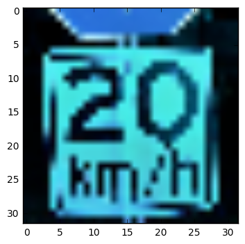

```python
speed_limit_stop_certainties = show_and_pred_certainty_image(speed_limit_stop)
```

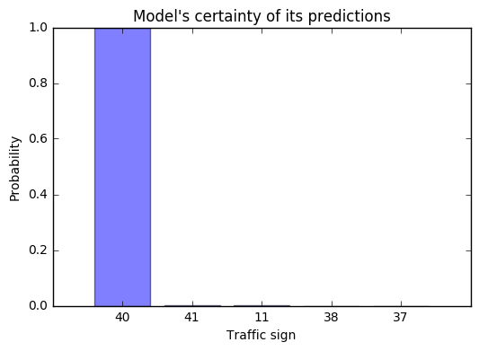

```
Traffic Sign Key
40 :  Roundabout mandatory
41 :  End of no passing
11 :  Right-of-way at the next intersection
38 :  Keep right
37 :  Go straight or left
```

```python
plot_certainty_arrays(speed_limit_stop_certainties[0][0],
                      speed_limit_stop_certainties[1][0])
```

```
Top five:  TopKV2(values=array([[  9.99970317e-01,   1.49008401e-05,   1.48288254e-05,
          5.40780825e-08,   3.71095841e-14]], dtype=float32), indices=array([[37, 34, 39, 38, 40]], dtype=int32))
```

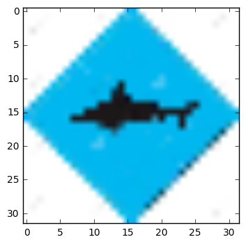

```python
shark_sign_certainties = show_and_pred_certainty_image(shark_sign)
```

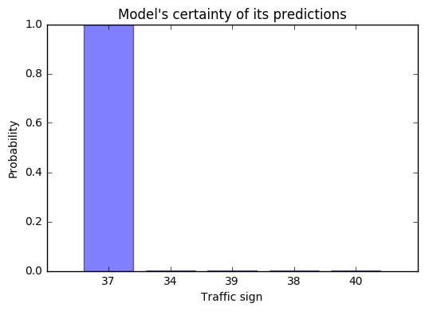

```
Traffic Sign Key
37 :  Go straight or left
34 :  Turn left ahead
39 :  Keep left
38 :  Keep right
40 :  Roundabout mandatory
```

```python
plot_certainty_arrays(shark_sign_certainties[0][0], shark_sign_certainties[1][0])
```

### Question 8

*Use the model's softmax probabilities to visualize the **certainty** of its predictions, [`tf.nn.top_k`](https://www.tensorflow.org/versions/r0.11/api_docs/python/nn.html#top_k) could prove helpful here. Which predictions is the model certain of? Uncertain? If the model was incorrect in its initial prediction, does the correct prediction appear in the top k? (k should be 5 at most)*

**Answer:**

(see code above)

These are both strange outcomes.

### Question 9

*If necessary, provide documentation for how an interface was built for your model to load and classify newly-acquired images.*

**Answer:** Not applicable at the moment.

```python
# Close the current session.
sess.close()
```